# Machine Learning to Classification Problems

Parash Upreti

June 20, 2016

### Overview

- This presentation covers the ways to create a machine learnining algorithm to classify cancerous cells. We will use differnt techniques and measure the accuracy of the prediction using each models.
- The dataset comes from UCI Machine Learning Recipotary. You can read about the dataset in the [website](http://archive.ics.uci.edu/ml/datasets/Breast+Cancer+Wisconsin+%28Diagnostic%29)
- Please note that this data is already cleaned and ready for use. So a majority of work is already done. Now we will use this data and predict if our algorithms can correctly classify.
- what is being covered are as follows: – Decision Trees – KNN – Naive Bayes – Support Vector Machines – Artifitial Neural Networks
- What is not being covered (will be covered separately) – Logistic Regression – Ensemble Methods – Other ML Algorithms – Cross Validation – Changing Default parameters and tuning models

### Getting the data

Download the data direcelty from the source to R. Please get acquinted with the data and the variable names. The following code chunk saves the data in the R environment as `wdbc` and provides the column name that we assign to it.

```r
#the dataset does not have headers and is a comma seperated dataset

link <- "http://archive.ics.uci.edu/ml/machine-learning-databases/breast-cancer-wisconsin/wdbc.data"

col_names<- c("id", "diagnosis", "radius_1", "texture_1", "perim_1", "area_1", "smooth_1", "compact_1", "concavity_1", "concave_pts_1", "symmetry_1", "frac_dim_1",
              "radius_2", "texture_2", "perim_2", "area_2", "smooth_2", "compact_2", "concavity_2", "concave_pts_2", "symmetry_2", "frac_dim_2",
              "radius_3", "texture_3", "perim_3", "area_3", "smooth_3", "compact_3", "concavity_3", "concave_pts_3", "symmetry_3", "frac_dim_3"          )

wdbc<- read.table(url(link), header = F, sep = ',', col.names = col_names)
```

Once the data is loaded to the R environment, it is import to explore it to understand the data itself. The results of following codes are hidden.

```r
head(wdbc, 5)   #shows us first 5 data, default is 6
tail(wdbc, 10)  #opposite of head
summary(wdbc)   #gives the five number summary for each quantitative variable
names(wdbc)     #the column names we assigned
str(wdbc)
```

These gives the basic idea of how the data are. From `str(wdbc)` it can be seen that all the variables are numerical and `diagnosis` is categorical with two levels, M and B. And our goal here will be to predict `diagnosis` based on other variables.

After some thought we realize that the column `id` is not necessary. So we remove it. Also remember that there are each cell nucleus is measured three different times using different methods (mean, standard error, and worst).

The scatter Matrix below shows how each variables are related to other

```r
wdbc<- wdbc[ ,-1]

wdbc[1, c('radius_1','radius_2','radius_3')]
```

```
##   radius_1 radius_2 radius_3
## 1    17.99    1.095    25.38
```

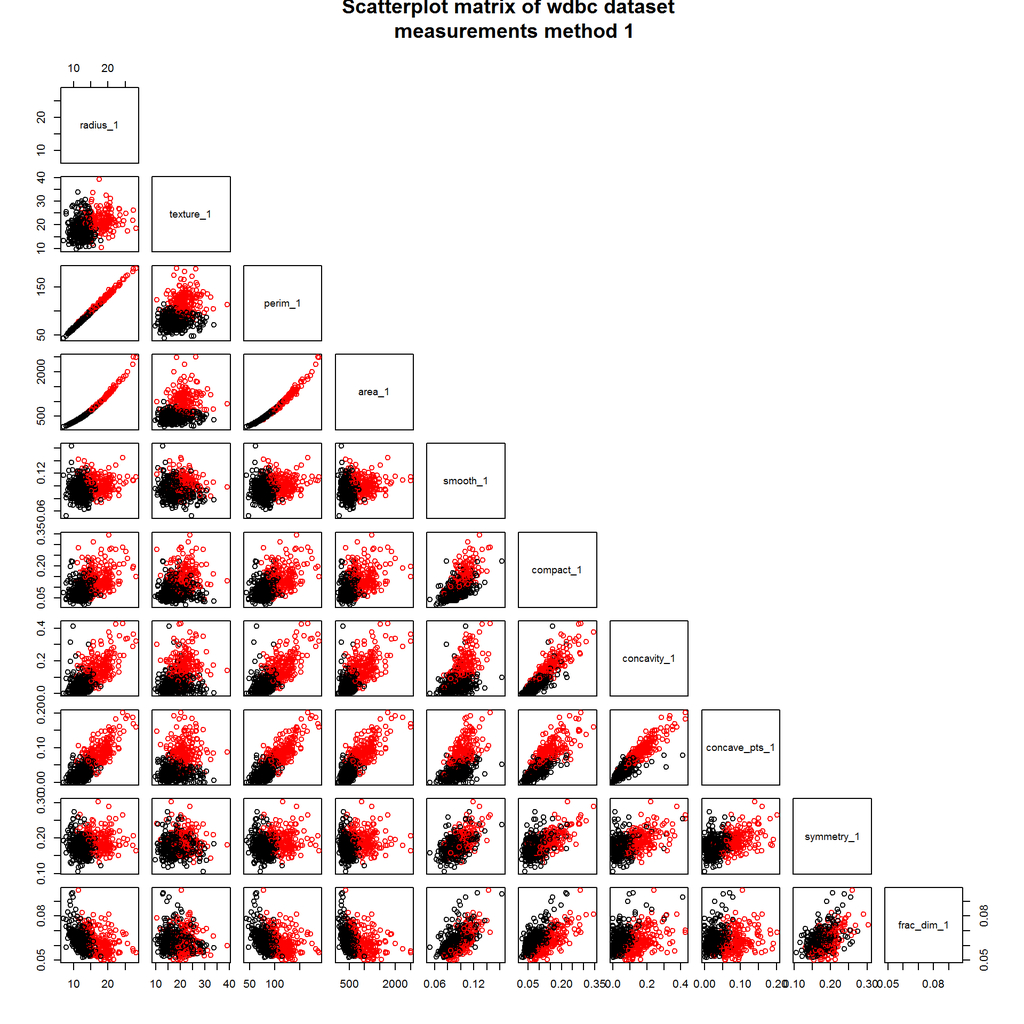

```r
pairs(wdbc[,2:11], upper.panel = NULL, col= wdbc$diagnosis,
      main ="Scatterplot matrix of wdbc dataset \n measurements method 1")
```

Notice that now there are only 31 columns now.

### Exploring dataset using statistics and plots (`ggplot2`)

A lot can be realized about the data through simple statistics and plots of the data. It is up to an individual data anaylst on how they want to explore the data before they start making the model. Following are a few ways data can be explored. Play with different built in functions and plots.

```r
# how many of instances of each diagnosis type are there?
table(wdbc$diagnosis)
```

```
##
##   B   M
## 357 212
```

```r
#previous question in terms of probablity
prop.table(table(wdbc$diagnosis))
```

```
##
##         B         M
## 0.6274165 0.3725835
```

```r
#using two variables
prop.table(table(wdbc$radius_1>11, wdbc$diagnosis ))
```

```
##
##                   B           M
##   FALSE 0.147627417 0.001757469
##   TRUE  0.479789104 0.370826011
```

```r
#'by' function helps group different columns together
by(wdbc$radius_1, wdbc$diagnosis, summary)
```

```
## wdbc$diagnosis: B
##    Min. 1st Qu.  Median    Mean 3rd Qu.    Max.
##   6.981  11.080  12.200  12.150  13.370  17.850
## --------------------------------------------------------
## wdbc$diagnosis: M
##    Min. 1st Qu.  Median    Mean 3rd Qu.    Max.
##   10.95   15.08   17.33   17.46   19.59   28.11
```

Can we say that malignant cells have bigger radius than benign cells?

### Quick tutorial of plotting in `ggplot2`

It is time to install and load `ggplot2` library

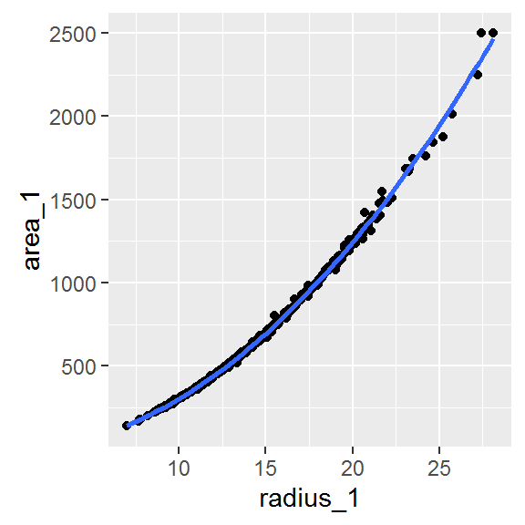

```r
library(ggplot2)
#plotting scatterplots of two points and adding smooth line
ggplot(aes(x = radius_1, y = area_1), data = wdbc)+
  geom_point()+geom_smooth()
```

```r
#correlation between two variables
cor(wdbc$radius_1, wdbc$area_1)
```

```
## [1] 0.9873572
```

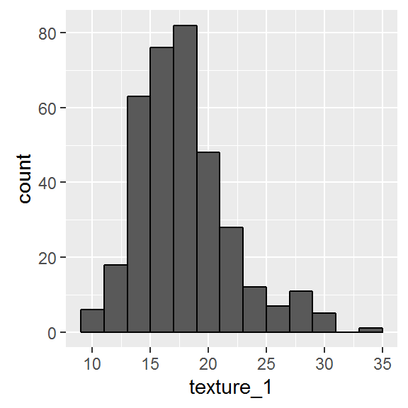

```r
#histogram of texture_1 where diagnosis = B
ggplot(aes(x= texture_1), data = subset(wdbc, diagnosis =="B"))+
  geom_histogram(binwidth =2, color =I("Black"))
```

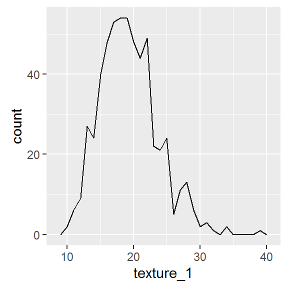

```r
#plotting two line graph from histogram
ggplot(aes(x= texture_1), data = wdbc)+ geom_freqpoly(binwidth =1)
```

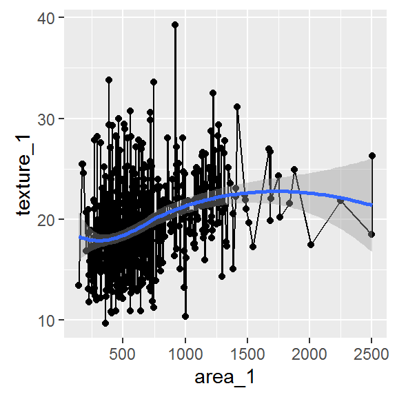

```r
#plotting bunch on of two variable things in one plot
ggplot(aes(x = area_1, y = texture_1), data = wdbc)+geom_line()+geom_point()+geom_smooth()
```

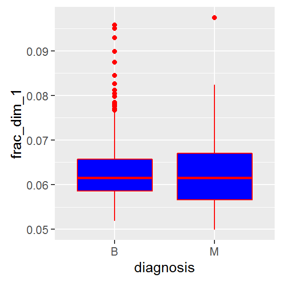

```r
#plotting boxplots
ggplot(aes(x =diagnosis, y = frac_dim_1, color = I("red"), fill = I("blue")),data = wdbc) +
  geom_boxplot()
```

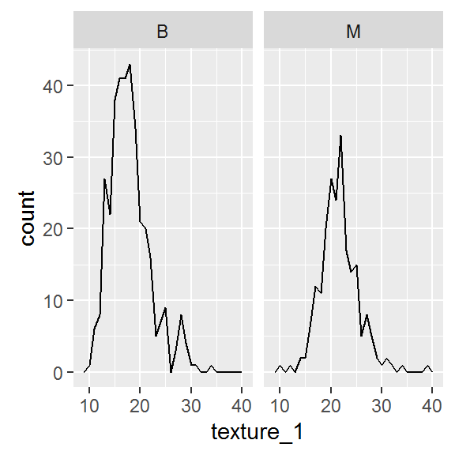

```r
#comparing same variable for two classes by faceting
ggplot(aes(x =texture_1), data = wdbc)+geom_freqpoly(binwidth = 1) +facet_wrap(~diagnosis)
```

There is much more to it. Note that base R plot functions can also produce similar. Best way to learn exploratory data analysis through ggplot is to ask interesting questions and try to plot it and see if you hypothesis comes true or not.

## Building our Machine Learning Algorithm

This will briefly cover some Machine Learning algorithm and how they can be used in making prediction. This will however not cover how to improve the models, change default parameters, doing cross validations and creating confusion matrices and using it to find the accuracy and error rates. They will be covered in the future.

We have aready created the most fundamental models. It is just simple guess and check method. Earlier we tabulated how many of the cells had radius >11 and which category they belonged to. That is a simple predictive model. However things are not always simple and they are affected by more than one variable. Machine Learning Algorithms help in such cases. Here are some algorithms that are widely used.

### Decision Trees

We will be using decision trees to classify the cells into `M` or `B` based on other variables. For theories on decision tree please read the textbook or this [Wikipedia entry] (https://en.wikipedia.org/wiki/Decision_tree)

Install and load the following `rpart`, `rpart.plot` and `rattle` libraries

```r
library(rpart)
library(rattle)
```

```r
library(rpart.plot)
#first decision tree model
first_dt<- rpart(diagnosis~., data = wdbc) #using all columns of wdbc as independent variables
first_dt
```

```
## n= 569
##
## node), split, n, loss, yval, (yprob)
##       * denotes terminal node
##
##  1) root 569 212 B (0.62741652 0.37258348)
##    2) radius_3< 16.795 379  33 B (0.91292876 0.08707124)
##      4) concave_pts_3< 0.1358 333   5 B (0.98498498 0.01501502) *
##      5) concave_pts_3>=0.1358 46  18 M (0.39130435 0.60869565)
##       10) texture_3< 25.67 19   4 B (0.78947368 0.21052632) *
##       11) texture_3>=25.67 27   3 M (0.11111111 0.88888889) *
##    3) radius_3>=16.795 190  11 M (0.05789474 0.94210526) *
```

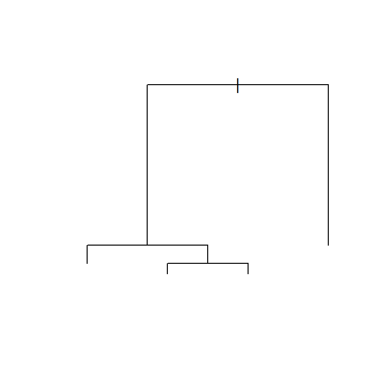

```r
#plotting the first tree
plot(first_dt)
```

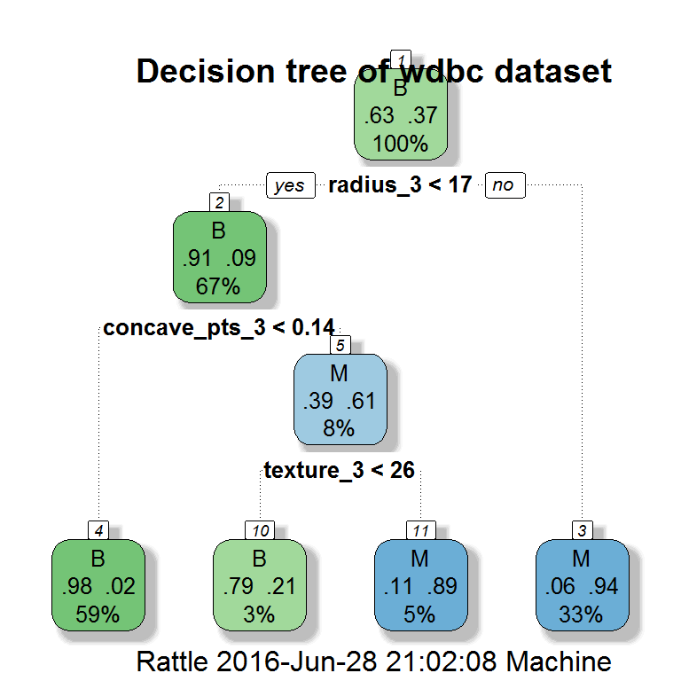

```r
#plotting "fancier" trees
fancyRpartPlot(first_dt, main = "Decision tree of wdbc dataset")
```

You can enter the code `summary(first_dt)` to see mathematical output of decision trees. In this example, we fed in all the data we had in the model. This gives us the output but this is not what we are looking for. This is called overfitting. We want to create a model so that when we feed in newer data, the model predicts the output for this data correctly.

To train our model, we will need to divide our dataset into two sets, training and testing sets. We will use training data to train the model and then test the validity of the model using the testing data.

```r
#setting seed so that the process is replicable with same results
set.seed(445)

#taking sample of rows, 70%, of wdbc data
sample_rows.wdbc<- sample(nrow(wdbc), round(.7*nrow(wdbc), 0))

train.wdbc<- wdbc[sample_rows.wdbc, ] #subsetting wdbc using sample from code above
test.wdbc<- wdbc[-sample_rows.wdbc, ] # -sample_rows.wdbc finds the rows that was not sampled

dim(wdbc)
```

```
## [1] 569  31
```

```r
dim(train.wdbc)
```

```
## [1] 398  31
```

```r
nrow(train.wdbc)+nrow(test.wdbc)== nrow(wdbc)
```

```
## [1] TRUE
```

So, now we have splitted the wdbc dataset into two separate dataset in no particular order. We can now build the model using training data and test using testing data

```r
wdbc.tree_1 <- rpart(diagnosis~., data = train.wdbc) #we are using default parameters

#predicting the outcome using our model above
predict.tree_1<- predict(wdbc.tree_1, newdata = test.wdbc, type = "class")
table(predict.tree_1)
```

```
## predict.tree_1
##   B   M
## 108  63
```

So, we predicted diagnosis results on testing set using the model we created by using training dataset. How do we know if our prediction is correct. Well, in this case we compare the result from our model against the true value in the test data.

```r
table(predict.tree_1, test.wdbc$diagnosis)
```

```
##
## predict.tree_1   B   M
##              B 101   7
##              M   6  57
```

Decision tree was a very easy solution to this problem because it recognized the important factors for the diagnosis in three splits with accuracy 0.9239766.

Will model predict as good if the data was sampled in different ways? In order to do that, we need to engineer the features and reduce overfitting. A simpler model that predicts well over longer term is a better model than a more complex model that only perfoms on certain data. We can also play with the tree default parameters. We will skip feature engineering and cross validation for now.

### Kth- Nearest Neighbours (KNN)

In Layman’s term, in KNN algorithm, the test data point finds the closest neighbour from the train data. The idea is that items with similar features live closer to each other.

```r
library(class)
# removing the categorical variables from both test and train dataset and telling knn to learn from diagnostics column from training dataset
wdbc.knn_1 <- knn(train = train.wdbc[, -1], test = test.wdbc[,-1], cl = train.wdbc$diagnosis, k = 5)

table(wdbc.knn_1, test.wdbc$diagnosis)
```

```
##
## wdbc.knn_1   B   M
##          B 102   9
##          M   5  55
```

This KNN model found the nearest 5 neighbours of the test point and classified it into whichever set `B` or `M` had at least 3 training set into it. The accuracy of prediction is 0.9181287

We did not normalize the data in this example. Normalization like Z score from X is necessary. Also , feature engineering and cross validation is skipped for now.

We will also use `kknn` package in the future and see the power of Kth- Nearest Neighbour algorighm.

### Naive Bayes

Naive Bayes classifier algorithm is the closest to the Baysian Model and it relies on probability of events happening prior. If you remember conditional probabilities from statistics, you are making good progress.

Install and load `e1071` library

```r
library(e1071)
wdbc.naive_1<- naiveBayes(diagnosis~.,data = train.wdbc)

predict.naive_1<- predict(wdbc.naive_1, newdata = test.wdbc, type = "class")

table(predict.naive_1, test.wdbc$diagnosis)
```

```
##
## predict.naive_1   B   M
##               B 101   8
##               M   6  56
```

With the basic naive bayes model we got the accuracy of 0.9181287

Again, there is a lot of optimization we can do using this method which is skipped here for now.

### Support Vector Machines

SVM is a very powerful techniques whose workings consists of applied math (linear algebra).

Install and load `e1071` library

```r
wdbc.svm_1<- svm(diagnosis~., data = train.wdbc)

predict.svm_1<- predict(wdbc.svm_1, newdata = test.wdbc)

table(predict.svm_1, test.wdbc$diagnosis)
```

```
##
## predict.svm_1   B   M
##             B 104   3
##             M   3  61
```

### Artifitial Neural Netrowks

Artifitial Neural Networks algorithm closely resemble the neurons or workings of brains. It consists of one input and output layer and multiple hidden ones.

Install and load the `nnet` library

```r
library(nnet)
wdbc.nnet_1 <- nnet(diagnosis~., data =  train.wdbc, size = 8)
predict.nnet_1<- predict(wdbc.nnet_1, newdata = test.wdbc, type ="class")

table(predict.nnet_1, test.wdbc$diagnosis)
```

```
##
## predict.nnet_1  B  M
##              B 97 10
##              M 10 54
```